# Lesson8

Sung Won Kang

2016년 12월 일

#### Data 준비

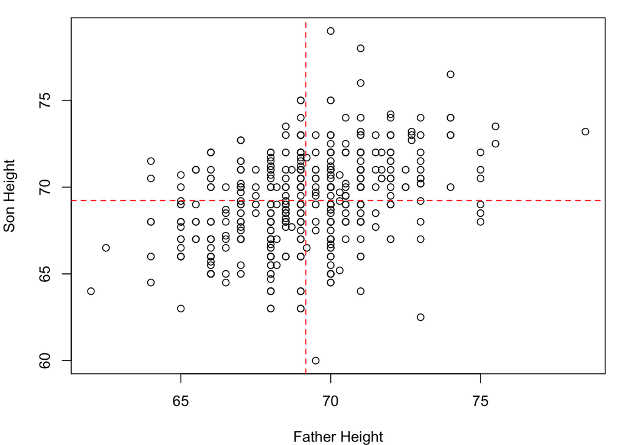

```r
#hf=read.csv("http://www.math.uah.edu/stat/data/Galton.csv",header=T,stringsAsFactors = FALSE)
#save(hf,file="Fatherson_o.rdata")
#load("Fatherson_o.Rdata")
#str(hf)
#str(hf$Gender)
#hf$Gender=factor(hf$Gender,levels=c("M","F"))
#str(hf$Gender)
#str(hf)

#hf.son=subset(hf,Gender=="M")
#str(hf.son)
#hf.son=hf.son[c("Father","Height")]
#str(hf.son)
#save(hf.son, file="Fatherson.Rdata")
load("Fatherson.rdata")
par(mar=c(4,4,1,1))
plot(hf.son$Father,hf.son$Height,xlab="Father Height",ylab="Son Height",mani="FS height")
abline(v=mean(hf.son$Father),col=2,lty=2)
abline(h=mean(hf.son$Height),col=2,lty=2)
```

# 상관계수

1. 공분산, 표본공분산
   $$\sigma_{xy}=E[(x-\mu_x)(y-\mu_y)],\qquad S_{xy}=\frac{\Sigma (X-\bar{X})(Y-\bar{Y})}{N-1}$$
2. 상관계수, 표본상관계수
   $$\rho_{xy}=\frac{E[(x-\mu_x)(y-\mu_y)]}{\sqrt{E(X-\mu_x)^2}\sqrt{E(X-\mu_y)^2}}=\frac{\sigma_{xy}}{\sigma_x\sigma_y}$$

$$r_{xy}=\frac{\Sigma (X-\bar{X})(Y-\bar{Y})}{\sqrt{\Sigma(X_i-\bar{X})^2}\sqrt{\Sigma(Y_i-\bar{Y})^2}}=\frac{S_{xy}}{S_x S_y}\\
S^2_x=\frac{\Sigma(X_i-\bar{X})^2}{N-1}\qquad S^2_y=\frac{\Sigma(Y_i-\bar{Y})^2}{N-1}$$

$$|\rho_{xy}|<1,|S_{xy}|<1$$
-1, 1에 가까우면 강한 상관관계, 0에 가까우면 약한 상관관계.

3. 복수의 확률변수 간의 상관계수: 분산-공분산 행렬

$$X = \{x_1, x_2,\cdots x_k\}$$
$$E(X)=E\begin{bmatrix}
x_1\\
x_2\\
\vdots\\
x_n
\end{bmatrix}
=
\begin{bmatrix}
\mu_1\\
\mu_2\\
\vdots\\
\mu_n
\end{bmatrix}=\mu$$

$$Cov(X)=E((X-\mu)(X-\mu)^T]=E\begin{bmatrix}
(X_1-\mu_1)(x_1-\mu_1)& (x_1-\mu_1)(x_2-\mu_2)&\cdots&(x_1-\mu_1)(x_n-\mu_n)\\
(X_2-\mu_2)(x_1-\mu_1)& (x_2-\mu_2)(x_2-\mu_2)&\cdots&(x_2-\mu_1)(x_n-\mu_n)\\
& &\vdots&\\
(X_n-\mu_n)(x_1-\mu_1)& (x_n-\mu_n)(x_2-\mu_2)&\cdots&(x_n-\mu_n)(x_n-\mu_n)
\end{bmatrix}$$

행렬 A에 확률변수 벡터 X를 곱하면 또 다른 학률변수 $AX$ 가 되고, 그 분산 공분산 행렬은 다음과 같다.

$$E(AX)=AE(X)=A\mu$$

$$Cov(AX)=E[(AX-A\mu)(AX-A\mu)^T]=E[A(X-\mu)(X-\mu)^TA^T]=AE[(X-\mu)(X-\mu)^T]A^T=ACov(X)A^T$$

# 회귀분석

## 추정식

$$y_i=\beta_0+\beta_1 x_i+\epsilon_i \quad i=1,2,\cdots,n\quad \epsilon_i\sim N(0,\sigma^2)$$
$$Y_{(n\times 1)}=[1, X]_{(n\times 2)}\beta_{(2\times 1)} +\epsilon_{(n\times 1)}\quad \epsilon\sim N (0,\sigma^2 I_{(n\times n)})$$
$$Y_{(n\times 1)}=X_{(n\times k)}\beta_{(k\times 1)} +\epsilon_{(n\times 1)}\quad\epsilon\sim N (0,\sigma^2 I_{(n\times n)})$$

1. $Y$ : 종속변수
2. $X$ : 독립변수
3. $\epsilon$ : 오차
4. $\beta_k$ : 회귀계수

$$\beta_k =\frac{\Delta Y}{\Delta X_k}=\frac{\partial Y}{\partial X}$$

- $X_k$ 1단위 변화에 따른 $Y$의 변화
- 다른 변수를 모두 동일하게 고정하고 $X_k$ 만 변화시켰을 경우의 $Y$의 변화 (net effect)

## 기본가정

1. i.i.d

$$Cov(\epsilon)=E(\epsilon\epsilon^T)=\sigma^2
\begin{bmatrix}
1&0&0&\dots\\
0&1&0&\dots\\
\dots&\dots&\dots&\dots\\
0&0&\dots&1
\end{bmatrix}
=\sigma^2 I$$

2. $X$ 와 $\epsilon$은 독립

$$E[\epsilon|X]=0,\qquad E[X^T\epsilon|X]=X^TE[\epsilon|X]=0$$

## 회귀계수의 추정

- 잔차(residual)의 제곱의 합을 가장 작게 하는 $\beta$ 를 찾음

$$\min_{\beta}\Sigma (Y_i-X_i^T\beta)^2=\min_{\beta}(Y-X\beta)^T(Y-X\beta)$$
$$\hat{\beta}=(X^TX)^{-1}(X^TY)$$

- $X=[1, x]$ 일 경우

$$(X^TX) =\begin{bmatrix}
1&1&\dots&1\\
x_1&x_2&\dots&x_n\\
\end{bmatrix}
\times
\begin{bmatrix}
1&x_1\\
1&x_2\\
\vdots&\vdots\\
1&x_n\\
\end{bmatrix}
=
\begin{bmatrix}
n&\sum x\\
\sum x & \sum x^2\\
\end{bmatrix}
\qquad
(X^TY) =\begin{bmatrix}
1&1&\dots&1\\
x_1&x_2&\dots&x_n\\
\end{bmatrix}
\times
\begin{bmatrix}
y_1\\
y_2\\
\vdots\\
y_n\\
\end{bmatrix}
=
\begin{bmatrix}
\sum y\\
\sum xy\\
\end{bmatrix}
\qquad$$

$$(X^TX)^{-1} =\frac{1}{[n\sum x^2-(\sum x )^2]}\begin{bmatrix}
\sum x^2&-\sum x\\
-\sum x & n\\
\end{bmatrix}\\$$
$$(X^TX)^{-1}(X^TY)=\frac{1}{[n\sum x^2-(\sum x )^2]}\begin{bmatrix}
\sum x^2&-\sum x\\
-\sum x & n\\
\end{bmatrix}
\begin{bmatrix}
\sum y\\
\sum xy\\
\end{bmatrix}\\$$

$$=\frac{1}{[n\sum x^2-(\sum x )^2]}\begin{bmatrix}
\sum x^2 \sum y-\sum x \sum x y\\
-\sum x \sum y+ n\sum xy\\
\end{bmatrix}\\$$

$$=\frac{1}{[n\sum x^2-n^2(\bar{x} )^2]}\begin{bmatrix}
n\sum x^2 \bar{y}-n\bar{x} \sum x y\\
-n^2\bar{x} \bar{y}+ n\sum xy\\
\end{bmatrix}\\$$

$$=\frac{1}{[\sum x^2-n(\bar{x} )^2]}\begin{bmatrix}
\sum x^2 \bar{y}-\bar{x} \sum x y\\
-n\bar{x} \bar{y}+ \sum xy\\
\end{bmatrix}\\$$

$$=\frac{1}{[\sum x^2-n(\bar{x} )^2]}\begin{bmatrix}
\sum x^2 \bar{y}-n\bar{x}^2\bar{y}+n\bar{x}^2\bar{y}-\bar{x} \sum x y\\
-n\bar{x} \bar{y}+ \sum xy\\
\end{bmatrix}\\$$

$$=\frac{1}{[\sum x^2-n(\bar{x} )^2]}\begin{bmatrix}
\bar{y}[\sum x^2 -n\bar{x}^2]-\bar{x}[\sum x y-n\bar{x}\bar{y}]\\
\sum xy-n\bar{x} \bar{y} \\
\end{bmatrix}\\$$

$$=\left [
\frac{\bar{y}[\sum x^2 -n\bar{x}^2]-\bar{x}[\sum x y-n\bar{x}\bar{y}]}{[\sum x^2-n(\bar{x} )^2]},\qquad
\frac{\sum xy-n\bar{x} \bar{y}}{[\sum x^2-n(\bar{x} )^2]} \right ]^T$$

$$= \left[\bar{y}-\bar{x}\frac{S_{xy}}{S^2_x},\qquad \frac{S_{xy}}{S^2_x}\right]^T$$

```r
n=dim(hf.son)[1]
x=as.matrix(cbind(rep(1,n),hf.son$Father))
y=as.matrix(hf.son$Height)
bhat=(solve(t(x)%*%x))%*% (t(x)%*%y)
bhat
```

```
##            [,1]
## [1,] 38.2589122
## [2,]  0.4477479
```

```r
(h.reg=lm(Height~Father,data=hf.son))
```

```
##
## Call:
## lm(formula = Height ~ Father, data = hf.son)
##
## Coefficients:
## (Intercept)       Father
##     38.2589       0.4477
```

```r
summary(h.reg)
```

```
##
## Call:
## lm(formula = Height ~ Father, data = hf.son)
##
## Residuals:
##     Min      1Q  Median      3Q     Max
## -9.3774 -1.4968  0.0181  1.6375  9.3987
##
## Coefficients:
##             Estimate Std. Error t value Pr(>|t|)
## (Intercept) 38.25891    3.38663   11.30   <2e-16 ***
## Father       0.44775    0.04894    9.15   <2e-16 ***
## ---
## Signif. codes:  0 '***' 0.001 '**' 0.01 '*' 0.05 '.' 0.1 ' ' 1
##
## Residual standard error: 2.424 on 463 degrees of freedom
## Multiple R-squared:  0.1531, Adjusted R-squared:  0.1513
## F-statistic: 83.72 on 1 and 463 DF,  p-value: < 2.2e-16
```

- 회귀분석은 수직거리가 가장 짧아지는 직선(평면)을 찾는다.

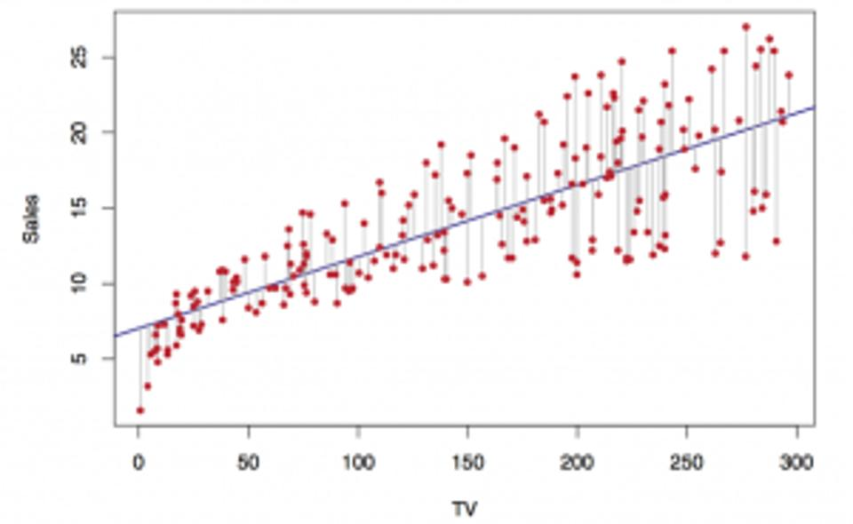

거리 최소화

## 회귀계수의 특징

$$\hat{\beta}=(X^TX)^{-1}(X^TY)=(X^TX)^{-1}(X^TX)\beta+(X^TX)^{-1}X^T\epsilon=\beta+(X^TX)^{-1}X^T\epsilon$$

### 평균: 불편성 (unbiasedness)

$$E[\hat{\beta}|X]=E[(X^TX)^{-1}(X^TY)|X]$$
$$=E[(X^TX)^{-1}(X^TX)\beta+(X^TX)^{-1}X^T\epsilon|X]$$
$$=\beta+E[(X^TX)^{-1}X^T\epsilon|X]$$
$$=\beta+(X^TX)^{-1}X^TE[\epsilon|X]=\beta$$
### 분산
$$Cov(\hat{\beta}|X)=E[(\hat{\beta}-\beta)(\hat{\beta}-\beta)^T|X]$$
$$=E[(X^TX)^{-1}X^T\epsilon\epsilon^TX(X^TX)^{-1}|X]$$
$$=(X^TX)^{-1}X^T\times E[\epsilon\epsilon^T|X]\times X(X^TX)^{-1}$$
$$=\sigma^2(X^TX)^{-1}X^TX(X^TX)^{-1}=\sigma^2(X^TX)^{-1}$$

### 분포

#### 회귀계수 : 정규분포

$$\hat{\beta} \sim N(\beta,\sigma^2(X^TX)^{-1})$$
$$\hat{\beta}_k \sim N(\beta_k,\sigma^2_k)\qquad \sigma^2_k=\sigma^2(X^TX)^{-1}_k=\mbox{kth diagonal of } (X^TX)^{-1}$$

#### 잔차항(residual) : $\chi^2$

- fitted value
  $$\hat{Y}=X\hat{\beta}$$
- 잔차항 : residual
  $$e\equiv Y-\hat{Y}=Y-X\hat{\beta}$$
  $$e^Te/\sigma^2 =\sum e_i^2/\sigma^2\sim\chi^2(n-k)$$
  $$s^2\equiv e^Te/(n-k),\qquad E(s^2|X)=E(e^Te/(n-k)|X)=\sigma^2$$

## 회귀분석

### 가설검정

#### 모형의 유의성 : F test

$$\sum (y-\bar{y})^2 =\sum (y-\hat{y})^2 +\sum (\hat{y}-\bar{y})^2$$

- $\sum(y-\bar{y})^2$ : Total Sum of Squres (TSS)
- $\sum(y-\hat{y})^2$ : Sum of Squred errors (SSE)
- $\sum(\hat{y}-\bar{y})^2$ : Regression Sum of Squres (RSS)
1. 가설
   $$H_0 :\beta_{j\neq 0}=0\qquad .vs \qquad H_1 :\exists j\neq 0\quad \beta_j\neq 0$$
2. 검정통계량
   $$\sum(y-\hat{y})^2\sim\chi^2(n-k), \qquad \sum(\hat{y}-\bar{y})^2\sim\chi^2(k-1,\lambda)\quad \mbox{ independent}$$
   $$F=\frac{\sum(\hat{y}-\bar{y})^2/(k-1)}{\sum(y-\hat{y})^2/(n-k)}\sim F(k-1,n-k,\lambda)$$

귀무가설 하에서는 $\lambda=0$ (Central F)

3. 기각역 : 단축검정 (오른쪽)
   $$P(f>C_u) = \alpha, (C_u,\infty ]$$
   $$pvalue=P[f>F]$$
4. 기각/채택 결정 : p-value < 2.2e-16 <0.05 $\rightarrow$ 귀무가설 기각

```r
(h.reg=lm(Height~Father,data=hf.son))
```

```
##
## Call:
## lm(formula = Height ~ Father, data = hf.son)
##
## Coefficients:
## (Intercept)       Father
##     38.2589       0.4477
```

```r
summary(h.reg)
```

```
##
## Call:
## lm(formula = Height ~ Father, data = hf.son)
##
## Residuals:
##     Min      1Q  Median      3Q     Max
## -9.3774 -1.4968  0.0181  1.6375  9.3987
##
## Coefficients:
##             Estimate Std. Error t value Pr(>|t|)
## (Intercept) 38.25891    3.38663   11.30   <2e-16 ***
## Father       0.44775    0.04894    9.15   <2e-16 ***
## ---
## Signif. codes:  0 '***' 0.001 '**' 0.01 '*' 0.05 '.' 0.1 ' ' 1
##
## Residual standard error: 2.424 on 463 degrees of freedom
## Multiple R-squared:  0.1531, Adjusted R-squared:  0.1513
## F-statistic: 83.72 on 1 and 463 DF,  p-value: < 2.2e-16
```

```r
s.h.reg=summary(h.reg)
s.h.reg$fstatistic
```

```
##     value     numdf     dendf
##  83.71863   1.00000 463.00000
```

```r
F=s.h.reg$fstatistic[1]
df1=s.h.reg$fstatistic[2]
df2=s.h.reg$fstatistic[3]

(p.value=1-pf(F,df1,df2))
```

```
## value
##     0
```

```r
(c.u=qf(1-0.05,df1,df2))
```

```
## [1] 3.861621
```

```r
ifelse(F>c.u,"Reject H0","Not reject H0")
```

```
##       value
## "Reject H0"
```

```r
#p.value<0.05

ifelse(p.value<0.05,"Reject H0","Not reject H0")
```

```
##       value
## "Reject H0"
```

#### 개별 계수의 유의성 : t test

1. 가설
   $$H_0:\beta_k=0\quad .vs \quad H_1:\beta_k\neq 0$$
2. 검정통계량

$\hat{\beta}$,$e$ 는 독립이다. 따라서
$$T=\frac{(\hat{\beta}_k-\beta_k)/\sigma\sqrt{(X^TX)^{-1}_k}}{\sqrt{e^Te/
\sigma^2(n-k)}}$$
$$=\frac{\hat{\beta}_k-\beta_k}
{\sigma\sqrt{(X^TX)^{-1}_k}\sqrt{e^Te/
\sigma^2(n-k)}}$$
$$=\frac{\hat{\beta}_k-\beta_k}{\sqrt{s^2
/(X^TX)^{-1}_k}}\sim t(n-k)$$

3. 기각역, 임계치 (유의수준 $\alpha$), p value
   $$P[|t|>c_{n-k,\alpha/2}]=\alpha, \quad (-c_{n-k,\alpha/2},c_{n-k,\alpha/2})$$
   $$P[t>|T|]$$

```r
s.h.reg$coefficients
```

```
##               Estimate Std. Error   t value     Pr(>|t|)
## (Intercept) 38.2589122 3.38663400 11.297032 2.642076e-26
## Father       0.4477479 0.04893533  9.149788 1.824016e-18
```

```r
(beta=s.h.reg$coefficients[,1])
```

```
## (Intercept)      Father
##  38.2589122   0.4477479
```

```r
(sdx=s.h.reg$coefficients[,2])
```

```
## (Intercept)      Father
##  3.38663400  0.04893533
```

```r
(tstats=s.h.reg$coefficients[,3])
```

```
## (Intercept)      Father
##   11.297032    9.149788
```

```r
(pvalue.t=s.h.reg$coefficients[,4])
```

```
##  (Intercept)       Father
## 2.642076e-26 1.824016e-18
```

### 모형의 평가 : 모형의 Fit (Goodnesss of fit) $R^2$

$$\sum (y-\bar{y})^2 =\sum (y-\hat{y})^2 +\sum (\hat{y}-\bar{y})^2$$
$$1 =\frac{\sum (y-\hat{y})^2}{\sum (y-\bar{y})^2} +\frac{\sum (\hat{y}-\bar{y})^2}{\sum (y-\bar{y})^2}$$
$$R^2=1 - \frac{\sum (y-\hat{y})^2}{\sum (y-\bar{y})^2}=\frac{\sum (\hat{y}-\bar{y})^2}{\sum (y-\bar{y})^2}$$

- $R^2$는 변수를 n 개를 사용하면 잔차항이 0 이 되어서 최대값인 1 이 된다. 이 경우에는 모든 sample 마다 그 sample을 설명하는 변수를 하나씩 갖게 되기 때문에 종속변수의 변화를 일으키는 주요 요인을 파악할 수 없게 된다. 하지만 $R^2$는 이러한 ’변수가 지나치게 많은 모형’을 더 좋은 모형으로 판단하는 단점이 있다.
- 이러한 단점을 극복하기 위해서 $R^2$를 개량하려는 시도는 많이 이루어졌지만, 특히 어떤 방법이 더 좋다는 결론은 내려져 있지 않다. 조정 $R^2$ (adjusted rsqure) 역시 이러한 시도의 한 예이다.

$$adj R^2 = 1-\frac{(1-R^2)(n-1)}{n-k-1}$$
n 이 아주 크면 $R^2$에 근접하지만, k (변수의 수) 가 증가하면 값이 하락한다.

### 추정 $E(Y|X)$

1. 회귀분석의 경우 주된 추정의 대상은 unknown parameter $\beta$ 및 종속변수 Y의 기대값 $E(y|X)$이다.
   $$E(Y|X)=E(X^T\beta+\epsilon|X)=X\beta$$
2. 특히 회귀분석은 새로운 독립변수 $X$에 대응하는 ‘아직 관찰되지 않은’ $Y$ 값의 기대값$E(Y|X)$를 추정하는 수단으로 자주 활용된다. 예를 들어 ‘배출규제 위반 벌금을 10% 올렸을 경우 배출량’ 을 추정하는 전형적인 정책 simulation의 경우 ’벌금 10% 인상’은 새로운 독립변수, ’배출량’은 그에 대응하는 종속변수의 값이다.
   $$Y_{n+1} =X_{n+1}\beta+\epsilon$$
   $$E(Y_{n+1}|X) =X_{n+1}\beta$$
3. $E(Y|X)$는 보이지 않는 값이기 때문에 추정량을 사용하여 추정하며, 따라서 신뢰구간이 존재한다.
   $$E(Y|X)=X\beta \Leftarrow X\hat{\beta}$$

#### $E(Y|X)$의 점추정

$$\hat{Y}=X\hat{\beta}=X(X^TX)^{-1}X^TY=P_xY$$

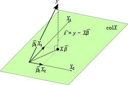

Regression and Projection

#### $E(Y|X)$의 구간추정

$$E(Y|X) = X\beta$$
$$\hat{Y}=X\hat{\beta}=X(X^TX)^{-1}X^{T}Y=X(X^TX)^{-1}X^{T}[X\beta+\epsilon]=X\beta+X(X^TX)^{-1}X^{T}\epsilon=X\beta +P_x\epsilon$$
$$\hat{Y} \sim N(X\beta, \sigma^2P_x)$$
$$\hat{Y}_i \sim N(X_i\beta,\sigma^2P_{x,i})\quad P_{x,i} :\mbox{ith diagonal of }P_x$$
$$T=\frac{\hat{Y}_i-X_i\beta}{s\sqrt{P_{x,i}}}\sim t(n-k)\qquad s=\sqrt{\sum (y-\hat{y})^2/(n-k)}$$

- 95% 신뢰구간은?
  $$C.I =(\hat{Y}_i-t_{n-k, 0.025}s\sqrt{P_{x,i}},\quad \hat{Y}_i+t_{n-k, 0.025}s\sqrt{P_{x,i}})$$

여기서 $X=[1,\quad x]$ 인 경우

$$P_{x,i}=\begin{bmatrix} 1 & x_i \end{bmatrix}
\frac{1}{[n\sum x^2-(\sum x )^2]}\begin{bmatrix}
\sum x^2&-\sum x\\
-\sum x & n\\
\end{bmatrix}
\begin{bmatrix}
1\\
x_i \end{bmatrix}$$
$$=\frac{1}{n}+\frac{(x_i-\bar{x})^2}{\sum(x-\bar{x})^2}$$
$$C.I =\left(\hat{Y}_i-t_{n-2, 0.025}s\sqrt{\frac{1}{n}+\frac{(x_i-\bar{x})^2}{\sum(x-\bar{x})^2}},\quad \hat{Y}_i+t_{n-2, 0.025}s\sqrt{\frac{1}{n}+\frac{(x_i-\bar{x})^2}{\sum(x-\bar{x})^2}}\right)$$
이러한 신뢰구간은 평균값에서 가장 작고, 평균에서 멀어질수록 값이 커진다.

#### 관측되지 않은 $E(Y_{n+1}|X)$ 추정

- 점추정치
  $$E(Y_{n+1}|X) =X_{n+1}\beta\leftarrow X_{n+1}\hat{\beta}$$
  $$\hat{Y}_{n+1}=X_{n+1}\hat{\beta}=X_{n+1}(X^TX)^{-1}X^{T}Y=X_{n+1}(X^TX)^{-1}X^{T}[X\beta+\epsilon]=X_{n+1}\beta+X_{n+1}(X^TX)^{-1}X^{T}\epsilon$$
  $$E(\hat{Y}_{n+1})=X_{n+1}\beta$$
  $$V(\hat{Y}_{n+1})=E[X_{n+1}(X^TX)^{-1}X^T\epsilon\epsilon^TX(X^TX)^{-1}X_{n+1}^T]$$
  $$= \sigma^2[X_{n+1}(X^TX)^{-1}X^TX(X^TX)^{-1}X_{n+1}^T]=\sigma^2X_{n+1}(X^TX)^{-1}X^T_{n+1}$$
  $$\hat{Y}_{n+1}\sim N(X_{n+1}\beta,\sigma^2X_{n+1}(X^TX)^{-1}X^T_{n+1})$$
- 95% 신뢰구간
  $$C.I =\left(\hat{Y}_{n+1}-t_{n-k, 0.025}s\sqrt{X_{n+1}(X^TX)^{-1}X^T_{n+1}},\quad \hat{Y}_{n+1}+t_{n-k, 0.025}s\sqrt{X_{n+1}(X^TX)^{-1}X^T_{n+1}}\right)$$

$X=[1, x]$ 인 경우

$$V(\hat{Y}_{n+1})=\begin{bmatrix} 1 & x_{n+1} \end{bmatrix}
\frac{1}{[n\sum x^2-(\sum x )^2]}\begin{bmatrix}
\sum x^2&-\sum x\\
-\sum x & n\\
\end{bmatrix}
\begin{bmatrix}
1\\
x_{n+1} \end{bmatrix}$$
$$=\frac{1}{n}+\frac{(x_{n+1}-\bar{x})^2}{\sum(x-\bar{x})^2}$$
$$C.I =\left(\hat{Y}_{n+1}-t_{n-2, 0.025}s\sqrt{\frac{1}{n}+\frac{(x_{n+1}-\bar{x})^2}{\sum(x-\bar{x})^2}},\quad \hat{Y}_{n+1}+t_{n-2, 0.025}s\sqrt{\frac{1}{n}+\frac{(x_{n+1}-\bar{x})^2}{\sum(x-\bar{x})^2}}\right)$$

#### Prediction interval: $Y_{n+1}$ 이 추정 대상일 경우

$$Y_{n+1}\sim N(X_{n+1}\beta,\epsilon)\quad \hat{Y}_{n+1}=X_{n+1}\hat{\beta}$$
$$\hat{Y}_{n+1}-Y_{n+1}=X_{n+1}\hat{\beta}-X_{n+1}\beta+\epsilon_{n+1}$$
$$X_{n+1}\hat{\beta}-X_{n+1}\beta=X_{n+1}(\hat{\beta}-\beta)\sim N(0,\sigma^2 X_{n+1}(X^TX)^{-1}X_{n+1}^T)$$
$$\epsilon_{n+1}\sim N(0,\sigma^2)$$
$$\hat{Y}_{n+1}-Y_{n+1}\sim N(0,\sigma^2\left[1+X_{n+1}(X^TX)^{-1}X_{n+1}^T\right])$$
이 경우의 신뢰구간을 Prediction interval 이라고 한다.

$$P.I =\left(\hat{Y}_{n+1}-t_{n-2, 0.025}s\sqrt{1+\frac{1}{n}+\frac{(x_{n+1}-\bar{x})^2}{\sum^n_{i=1}(x-\bar{x})^2}},\quad \hat{Y}_{n+1}+t_{n-2, 0.025}s\sqrt{1+\frac{1}{n}+\frac{(x_{n+1}-\bar{x})^2}{\sum^n_{i=1}(x-\bar{x})^2}}\right)$$

아래 그림에서 확인할 수 있듯이, $Y$ 에 대한 신뢰구간은 $E(Y|X)$ 에 대한 신뢰구간보다 훨씬 넓다. 추정치의 불확실성과 오류항의 불확실성이 모두 반영되기 때문이다.

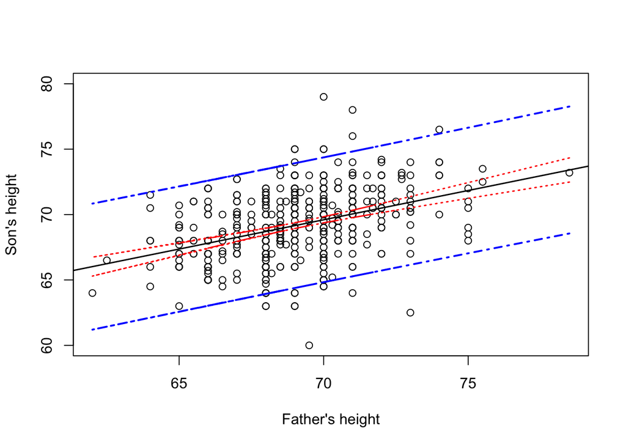

```r
# 그림 9-5
#no <- par(no.readonly = TRUE)
#par(mar=c(2,2,2,1))
plot(Height~Father, data=hf.son, main="",
     xlab="Father's height", ylab="Son's height",
     ylim=c(60, 80)
     )
abline(h.reg, lwd=1.5)
ci <- predict(h.reg, interval="confidence")
prd <- predict(h.reg, interval="predict")
lines(hf.son$Father, ci[,2], lty=3, lwd=1.5, col="red")
lines(hf.son$Father, ci[,3], lty=3, lwd=1.5, col="red")
lines(hf.son$Father, prd[,2],lty=4, lwd=2,col="blue")
lines(hf.son$Father, prd[,3],lty=4, lwd=2,col="blue")
```

```r
#par(no)
```